# Risk Factor Analysis

## Outcome Variable

**Outcome Variable:** pers_wast

## Predictor Variables

**Intervention Variable:** brthmon

**Adjustment Set:**

unadjusted

## Stratifying Variables

The analysis was stratified on these variable(s):

- agecat
- studyid
- country

## Data Summary

| agecat | studyid | country | brthmon | pers_wast | n_cell | n |
| --- | --- | --- | --- | --- | --- | --- |
| 0-24 months | CMC-V-BCS-2002 | INDIA | 1 | 0 | 31 | 373 |
| 0-24 months | CMC-V-BCS-2002 | INDIA | 1 | 1 | 3 | 373 |
| 0-24 months | CMC-V-BCS-2002 | INDIA | 2 | 0 | 14 | 373 |
| 0-24 months | CMC-V-BCS-2002 | INDIA | 2 | 1 | 2 | 373 |
| 0-24 months | CMC-V-BCS-2002 | INDIA | 3 | 0 | 31 | 373 |
| 0-24 months | CMC-V-BCS-2002 | INDIA | 3 | 1 | 0 | 373 |
| 0-24 months | CMC-V-BCS-2002 | INDIA | 4 | 0 | 41 | 373 |
| 0-24 months | CMC-V-BCS-2002 | INDIA | 4 | 1 | 3 | 373 |
| 0-24 months | CMC-V-BCS-2002 | INDIA | 5 | 0 | 32 | 373 |
| 0-24 months | CMC-V-BCS-2002 | INDIA | 5 | 1 | 4 | 373 |
| 0-24 months | CMC-V-BCS-2002 | INDIA | 6 | 0 | 36 | 373 |
| 0-24 months | CMC-V-BCS-2002 | INDIA | 6 | 1 | 1 | 373 |
| 0-24 months | CMC-V-BCS-2002 | INDIA | 7 | 0 | 37 | 373 |
| 0-24 months | CMC-V-BCS-2002 | INDIA | 7 | 1 | 2 | 373 |
| 0-24 months | CMC-V-BCS-2002 | INDIA | 8 | 0 | 17 | 373 |
| 0-24 months | CMC-V-BCS-2002 | INDIA | 8 | 1 | 1 | 373 |
| 0-24 months | CMC-V-BCS-2002 | INDIA | 9 | 0 | 20 | 373 |
| 0-24 months | CMC-V-BCS-2002 | INDIA | 9 | 1 | 1 | 373 |
| 0-24 months | CMC-V-BCS-2002 | INDIA | 10 | 0 | 27 | 373 |
| 0-24 months | CMC-V-BCS-2002 | INDIA | 10 | 1 | 2 | 373 |
| 0-24 months | CMC-V-BCS-2002 | INDIA | 11 | 0 | 41 | 373 |
| 0-24 months | CMC-V-BCS-2002 | INDIA | 11 | 1 | 2 | 373 |
| 0-24 months | CMC-V-BCS-2002 | INDIA | 12 | 0 | 23 | 373 |
| 0-24 months | CMC-V-BCS-2002 | INDIA | 12 | 1 | 2 | 373 |
| 0-24 months | CMIN | BANGLADESH | 1 | 0 | 26 | 257 |
| 0-24 months | CMIN | BANGLADESH | 1 | 1 | 2 | 257 |
| 0-24 months | CMIN | BANGLADESH | 2 | 0 | 23 | 257 |
| 0-24 months | CMIN | BANGLADESH | 2 | 1 | 2 | 257 |
| 0-24 months | CMIN | BANGLADESH | 3 | 0 | 16 | 257 |
| 0-24 months | CMIN | BANGLADESH | 3 | 1 | 3 | 257 |

[output cut: 1770 more lines]

The following strata were considered:

- agecat: 0-24 months, studyid: CMC-V-BCS-2002, country: INDIA
- agecat: 0-24 months, studyid: CMIN, country: BANGLADESH
- agecat: 0-24 months, studyid: CONTENT, country: PERU
- agecat: 0-24 months, studyid: EE, country: PAKISTAN
- agecat: 0-24 months, studyid: GMS-Nepal, country: NEPAL
- agecat: 0-24 months, studyid: Guatemala BSC, country: GUATEMALA
- agecat: 0-24 months, studyid: iLiNS-Zinc, country: BURKINA FASO
- agecat: 0-24 months, studyid: IRC, country: INDIA
- agecat: 0-24 months, studyid: JiVitA-3, country: BANGLADESH
- agecat: 0-24 months, studyid: JiVitA-4, country: BANGLADESH
- agecat: 0-24 months, studyid: Keneba, country: GAMBIA
- agecat: 0-24 months, studyid: LCNI-5, country: MALAWI
- agecat: 0-24 months, studyid: MAL-ED, country: BANGLADESH
- agecat: 0-24 months, studyid: MAL-ED, country: BRAZIL
- agecat: 0-24 months, studyid: MAL-ED, country: INDIA
- agecat: 0-24 months, studyid: MAL-ED, country: NEPAL
- agecat: 0-24 months, studyid: MAL-ED, country: PERU
- agecat: 0-24 months, studyid: MAL-ED, country: SOUTH AFRICA
- agecat: 0-24 months, studyid: MAL-ED, country: TANZANIA, UNITED REPUBLIC OF
- agecat: 0-24 months, studyid: NIH-Birth, country: BANGLADESH
- agecat: 0-24 months, studyid: PROBIT, country: BELARUS
- agecat: 0-24 months, studyid: PROVIDE, country: BANGLADESH
- agecat: 0-24 months, studyid: ResPak, country: PAKISTAN
- agecat: 0-24 months, studyid: SAS-CompFeed, country: INDIA
- agecat: 0-24 months, studyid: SAS-FoodSuppl, country: INDIA
- agecat: 0-24 months, studyid: TanzaniaChild2, country: TANZANIA, UNITED REPUBLIC OF
- agecat: 0-24 months, studyid: ZVITAMBO, country: ZIMBABWE
- agecat: 0-6 months, studyid: CMC-V-BCS-2002, country: INDIA
- agecat: 0-6 months, studyid: CMIN, country: BANGLADESH
- agecat: 0-6 months, studyid: CONTENT, country: PERU
- agecat: 0-6 months, studyid: EE, country: PAKISTAN
- agecat: 0-6 months, studyid: GMS-Nepal, country: NEPAL
- agecat: 0-6 months, studyid: IRC, country: INDIA
- agecat: 0-6 months, studyid: JiVitA-3, country: BANGLADESH
- agecat: 0-6 months, studyid: Keneba, country: GAMBIA
- agecat: 0-6 months, studyid: MAL-ED, country: BANGLADESH
- agecat: 0-6 months, studyid: MAL-ED, country: BRAZIL
- agecat: 0-6 months, studyid: MAL-ED, country: INDIA
- agecat: 0-6 months, studyid: MAL-ED, country: NEPAL
- agecat: 0-6 months, studyid: MAL-ED, country: PERU
- agecat: 0-6 months, studyid: MAL-ED, country: SOUTH AFRICA
- agecat: 0-6 months, studyid: MAL-ED, country: TANZANIA, UNITED REPUBLIC OF
- agecat: 0-6 months, studyid: NIH-Birth, country: BANGLADESH
- agecat: 0-6 months, studyid: PROBIT, country: BELARUS
- agecat: 0-6 months, studyid: PROVIDE, country: BANGLADESH
- agecat: 0-6 months, studyid: ResPak, country: PAKISTAN
- agecat: 0-6 months, studyid: TanzaniaChild2, country: TANZANIA, UNITED REPUBLIC OF
- agecat: 0-6 months, studyid: ZVITAMBO, country: ZIMBABWE
- agecat: 6-24 months, studyid: CMC-V-BCS-2002, country: INDIA
- agecat: 6-24 months, studyid: CMIN, country: BANGLADESH
- agecat: 6-24 months, studyid: CONTENT, country: PERU
- agecat: 6-24 months, studyid: EE, country: PAKISTAN
- agecat: 6-24 months, studyid: GMS-Nepal, country: NEPAL
- agecat: 6-24 months, studyid: Guatemala BSC, country: GUATEMALA
- agecat: 6-24 months, studyid: iLiNS-Zinc, country: BURKINA FASO
- agecat: 6-24 months, studyid: IRC, country: INDIA
- agecat: 6-24 months, studyid: JiVitA-3, country: BANGLADESH
- agecat: 6-24 months, studyid: JiVitA-4, country: BANGLADESH
- agecat: 6-24 months, studyid: Keneba, country: GAMBIA
- agecat: 6-24 months, studyid: LCNI-5, country: MALAWI
- agecat: 6-24 months, studyid: MAL-ED, country: BANGLADESH
- agecat: 6-24 months, studyid: MAL-ED, country: BRAZIL
- agecat: 6-24 months, studyid: MAL-ED, country: INDIA
- agecat: 6-24 months, studyid: MAL-ED, country: NEPAL
- agecat: 6-24 months, studyid: MAL-ED, country: PERU
- agecat: 6-24 months, studyid: MAL-ED, country: SOUTH AFRICA
- agecat: 6-24 months, studyid: MAL-ED, country: TANZANIA, UNITED REPUBLIC OF
- agecat: 6-24 months, studyid: NIH-Birth, country: BANGLADESH
- agecat: 6-24 months, studyid: PROBIT, country: BELARUS
- agecat: 6-24 months, studyid: PROVIDE, country: BANGLADESH
- agecat: 6-24 months, studyid: ResPak, country: PAKISTAN
- agecat: 6-24 months, studyid: SAS-CompFeed, country: INDIA
- agecat: 6-24 months, studyid: SAS-FoodSuppl, country: INDIA
- agecat: 6-24 months, studyid: TanzaniaChild2, country: TANZANIA, UNITED REPUBLIC OF
- agecat: 6-24 months, studyid: ZVITAMBO, country: ZIMBABWE

### Dropped Strata

Some strata were dropped due to rare outcomes:

- agecat: 0-24 months, studyid: CMC-V-BCS-2002, country: INDIA
- agecat: 0-24 months, studyid: CMIN, country: BANGLADESH
- agecat: 0-24 months, studyid: CONTENT, country: PERU
- agecat: 0-24 months, studyid: EE, country: PAKISTAN
- agecat: 0-24 months, studyid: GMS-Nepal, country: NEPAL
- agecat: 0-24 months, studyid: Guatemala BSC, country: GUATEMALA
- agecat: 0-24 months, studyid: IRC, country: INDIA
- agecat: 0-24 months, studyid: JiVitA-4, country: BANGLADESH
- agecat: 0-24 months, studyid: LCNI-5, country: MALAWI
- agecat: 0-24 months, studyid: MAL-ED, country: BANGLADESH
- agecat: 0-24 months, studyid: MAL-ED, country: BRAZIL
- agecat: 0-24 months, studyid: MAL-ED, country: INDIA
- agecat: 0-24 months, studyid: MAL-ED, country: NEPAL
- agecat: 0-24 months, studyid: MAL-ED, country: PERU
- agecat: 0-24 months, studyid: MAL-ED, country: SOUTH AFRICA
- agecat: 0-24 months, studyid: MAL-ED, country: TANZANIA, UNITED REPUBLIC OF
- agecat: 0-24 months, studyid: NIH-Birth, country: BANGLADESH
- agecat: 0-24 months, studyid: PROBIT, country: BELARUS
- agecat: 0-24 months, studyid: PROVIDE, country: BANGLADESH
- agecat: 0-24 months, studyid: ResPak, country: PAKISTAN
- agecat: 0-24 months, studyid: SAS-FoodSuppl, country: INDIA
- agecat: 0-24 months, studyid: TanzaniaChild2, country: TANZANIA, UNITED REPUBLIC OF
- agecat: 0-6 months, studyid: CMC-V-BCS-2002, country: INDIA
- agecat: 0-6 months, studyid: CMIN, country: BANGLADESH
- agecat: 0-6 months, studyid: CONTENT, country: PERU
- agecat: 0-6 months, studyid: EE, country: PAKISTAN
- agecat: 0-6 months, studyid: GMS-Nepal, country: NEPAL
- agecat: 0-6 months, studyid: IRC, country: INDIA
- agecat: 0-6 months, studyid: JiVitA-3, country: BANGLADESH
- agecat: 0-6 months, studyid: Keneba, country: GAMBIA
- agecat: 0-6 months, studyid: MAL-ED, country: BANGLADESH
- agecat: 0-6 months, studyid: MAL-ED, country: BRAZIL
- agecat: 0-6 months, studyid: MAL-ED, country: INDIA
- agecat: 0-6 months, studyid: MAL-ED, country: NEPAL
- agecat: 0-6 months, studyid: MAL-ED, country: PERU
- agecat: 0-6 months, studyid: MAL-ED, country: SOUTH AFRICA
- agecat: 0-6 months, studyid: MAL-ED, country: TANZANIA, UNITED REPUBLIC OF
- agecat: 0-6 months, studyid: NIH-Birth, country: BANGLADESH
- agecat: 0-6 months, studyid: PROVIDE, country: BANGLADESH
- agecat: 0-6 months, studyid: ResPak, country: PAKISTAN
- agecat: 0-6 months, studyid: TanzaniaChild2, country: TANZANIA, UNITED REPUBLIC OF
- agecat: 0-6 months, studyid: ZVITAMBO, country: ZIMBABWE
- agecat: 6-24 months, studyid: CMC-V-BCS-2002, country: INDIA
- agecat: 6-24 months, studyid: CMIN, country: BANGLADESH
- agecat: 6-24 months, studyid: CONTENT, country: PERU
- agecat: 6-24 months, studyid: EE, country: PAKISTAN
- agecat: 6-24 months, studyid: GMS-Nepal, country: NEPAL
- agecat: 6-24 months, studyid: Guatemala BSC, country: GUATEMALA
- agecat: 6-24 months, studyid: IRC, country: INDIA
- agecat: 6-24 months, studyid: JiVitA-4, country: BANGLADESH
- agecat: 6-24 months, studyid: LCNI-5, country: MALAWI
- agecat: 6-24 months, studyid: MAL-ED, country: BANGLADESH
- agecat: 6-24 months, studyid: MAL-ED, country: BRAZIL
- agecat: 6-24 months, studyid: MAL-ED, country: INDIA
- agecat: 6-24 months, studyid: MAL-ED, country: NEPAL
- agecat: 6-24 months, studyid: MAL-ED, country: PERU
- agecat: 6-24 months, studyid: MAL-ED, country: SOUTH AFRICA
- agecat: 6-24 months, studyid: MAL-ED, country: TANZANIA, UNITED REPUBLIC OF
- agecat: 6-24 months, studyid: NIH-Birth, country: BANGLADESH
- agecat: 6-24 months, studyid: PROBIT, country: BELARUS
- agecat: 6-24 months, studyid: PROVIDE, country: BANGLADESH
- agecat: 6-24 months, studyid: ResPak, country: PAKISTAN
- agecat: 6-24 months, studyid: SAS-FoodSuppl, country: INDIA
- agecat: 6-24 months, studyid: TanzaniaChild2, country: TANZANIA, UNITED REPUBLIC OF

## Methods Detail

We’re interested in the causal parameters $E[Y_a]$ for all values of $a \in \mathcal{A}$. These parameters represent the mean outcome if, possibly contrary to fact, we intervened to set all units to have $A=a$. Under the randomization and positivity assumptions, these are identified by the statistical parameters $\psi_a=E_W[E_{Y|A,W}(Y|A=a,W)]$. In addition, we’re interested in the mean of $Y$, $E[Y]$ under no intervention (the observed mean). We will estimate these parameters by using SuperLearner to fit the relevant likelihood factors – $E_{Y|A,W}(Y|A=a,W)$ and $p(A=a|W)$, and then updating our likelihood fit using a joint TMLE.

For unadjusted analyses ($W=\{\}$), initial likelihoods were estimated using Lrnr_glm to estimate the simple $E(Y|A)$ and Lrnr_mean to estimate $p(A)$. For adjusted analyses, a small library containing Lrnr_glmnet, Lrnr_xgboost, and Lrnr_mean was used.

Having estimated these parameters, we will then use the delta method to estimate relative risks and attributable risks relative to a prespecified baseline level of $A$.

# Results Detail

## Results Plots

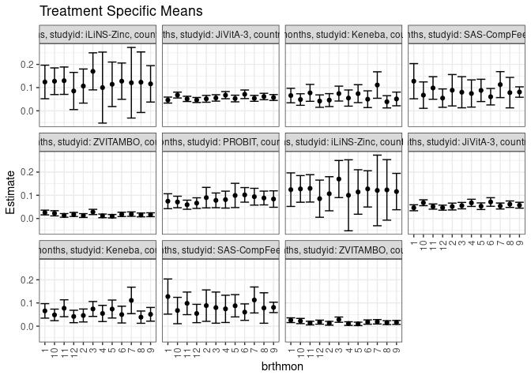

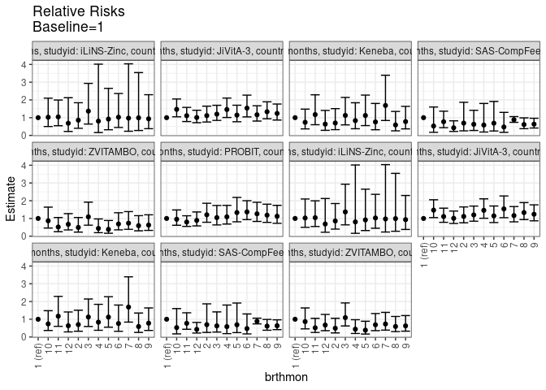

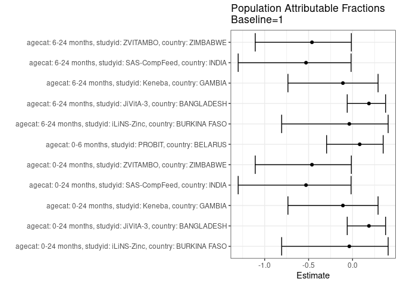

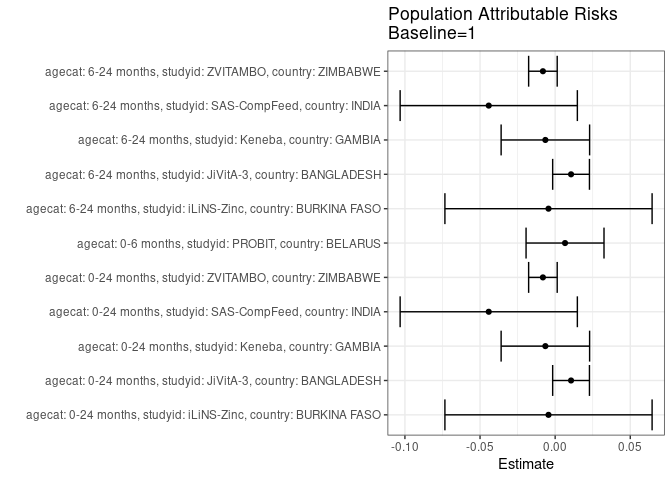

## Results Table

### Parameter: TSM

| agecat | studyid | country | intervention_level | baseline_level | estimate | ci_lower | ci_upper |
| --- | --- | --- | --- | --- | --- | --- | --- |
| 0-24 months | iLiNS-Zinc | BURKINA FASO | 1 | NA | 0.1242604 | 0.0519852 | 0.1965355 |
| 0-24 months | iLiNS-Zinc | BURKINA FASO | 2 | NA | 0.1066667 | 0.0332501 | 0.1800833 |
| 0-24 months | iLiNS-Zinc | BURKINA FASO | 3 | NA | 0.1700000 | 0.0900929 | 0.2499071 |
| 0-24 months | iLiNS-Zinc | BURKINA FASO | 4 | NA | 0.1000000 | -0.0529678 | 0.2529678 |
| 0-24 months | iLiNS-Zinc | BURKINA FASO | 5 | NA | 0.1142857 | 0.0183912 | 0.2101802 |
| 0-24 months | iLiNS-Zinc | BURKINA FASO | 6 | NA | 0.1276596 | 0.0495349 | 0.2057843 |
| 0-24 months | iLiNS-Zinc | BURKINA FASO | 7 | NA | 0.1208791 | -0.0312476 | 0.2730059 |
| 0-24 months | iLiNS-Zinc | BURKINA FASO | 8 | NA | 0.1231884 | -0.0072348 | 0.2536116 |
| 0-24 months | iLiNS-Zinc | BURKINA FASO | 9 | NA | 0.1160714 | 0.0377125 | 0.1944303 |
| 0-24 months | iLiNS-Zinc | BURKINA FASO | 10 | NA | 0.1274510 | 0.0700414 | 0.1848606 |
| 0-24 months | iLiNS-Zinc | BURKINA FASO | 11 | NA | 0.1297297 | 0.0707601 | 0.1886994 |
| 0-24 months | iLiNS-Zinc | BURKINA FASO | 12 | NA | 0.0853659 | 0.0053251 | 0.1654066 |
| 0-24 months | JiVitA-3 | BANGLADESH | 1 | NA | 0.0462382 | 0.0333746 | 0.0591019 |
| 0-24 months | JiVitA-3 | BANGLADESH | 2 | NA | 0.0516304 | 0.0369393 | 0.0663215 |
| 0-24 months | JiVitA-3 | BANGLADESH | 3 | NA | 0.0554340 | 0.0416255 | 0.0692425 |
| 0-24 months | JiVitA-3 | BANGLADESH | 4 | NA | 0.0674357 | 0.0520232 | 0.0828481 |
| 0-24 months | JiVitA-3 | BANGLADESH | 5 | NA | 0.0529301 | 0.0386629 | 0.0671972 |
| 0-24 months | JiVitA-3 | BANGLADESH | 6 | NA | 0.0711775 | 0.0527738 | 0.0895812 |
| 0-24 months | JiVitA-3 | BANGLADESH | 7 | NA | 0.0537634 | 0.0408915 | 0.0666354 |
| 0-24 months | JiVitA-3 | BANGLADESH | 8 | NA | 0.0615942 | 0.0476924 | 0.0754960 |
| 0-24 months | JiVitA-3 | BANGLADESH | 9 | NA | 0.0572570 | 0.0445208 | 0.0699932 |
| 0-24 months | JiVitA-3 | BANGLADESH | 10 | NA | 0.0678617 | 0.0552384 | 0.0804850 |
| 0-24 months | JiVitA-3 | BANGLADESH | 11 | NA | 0.0513784 | 0.0401735 | 0.0625834 |
| 0-24 months | JiVitA-3 | BANGLADESH | 12 | NA | 0.0466216 | 0.0358572 | 0.0573861 |
| 0-24 months | Keneba | GAMBIA | 1 | NA | 0.0658436 | 0.0346547 | 0.0970326 |
| 0-24 months | Keneba | GAMBIA | 2 | NA | 0.0460829 | 0.0181811 | 0.0739848 |
| 0-24 months | Keneba | GAMBIA | 3 | NA | 0.0742188 | 0.0421023 | 0.1063352 |
| 0-24 months | Keneba | GAMBIA | 4 | NA | 0.0548780 | 0.0200156 | 0.0897405 |
| 0-24 months | Keneba | GAMBIA | 5 | NA | 0.0738636 | 0.0352151 | 0.1125122 |
| 0-24 months | Keneba | GAMBIA | 6 | NA | 0.0500000 | 0.0138906 | 0.0861094 |

[output cut: 102 more lines]

### Parameter: E(Y)

| agecat | studyid | country | intervention_level | baseline_level | estimate | ci_lower | ci_upper |
| --- | --- | --- | --- | --- | --- | --- | --- |
| 0-24 months | iLiNS-Zinc | BURKINA FASO | NA | NA | 0.1198322 | 0.0943748 | 0.1452897 |
| 0-24 months | JiVitA-3 | BANGLADESH | NA | NA | 0.0568247 | 0.0527145 | 0.0609348 |
| 0-24 months | Keneba | GAMBIA | NA | NA | 0.0593290 | 0.0499611 | 0.0686968 |
| 0-24 months | SAS-CompFeed | INDIA | NA | NA | 0.0834553 | 0.0601989 | 0.1067118 |
| 0-24 months | ZVITAMBO | ZIMBABWE | NA | NA | 0.0176341 | 0.0149910 | 0.0202771 |
| 0-6 months | PROBIT | BELARUS | NA | NA | 0.0810551 | 0.0555982 | 0.1065120 |
| 6-24 months | iLiNS-Zinc | BURKINA FASO | NA | NA | 0.1198322 | 0.0943748 | 0.1452897 |
| 6-24 months | JiVitA-3 | BANGLADESH | NA | NA | 0.0568247 | 0.0527145 | 0.0609348 |
| 6-24 months | Keneba | GAMBIA | NA | NA | 0.0593290 | 0.0499611 | 0.0686968 |
| 6-24 months | SAS-CompFeed | INDIA | NA | NA | 0.0834553 | 0.0601989 | 0.1067118 |
| 6-24 months | ZVITAMBO | ZIMBABWE | NA | NA | 0.0176341 | 0.0149910 | 0.0202771 |

### Parameter: RR

| agecat | studyid | country | intervention_level | baseline_level | estimate | ci_lower | ci_upper |
| --- | --- | --- | --- | --- | --- | --- | --- |
| 0-24 months | iLiNS-Zinc | BURKINA FASO | 1 | 1 | 1.0000000 | 1.0000000 | 1.0000000 |
| 0-24 months | iLiNS-Zinc | BURKINA FASO | 2 | 1 | 0.8584127 | 0.3999918 | 1.8422188 |
| 0-24 months | iLiNS-Zinc | BURKINA FASO | 3 | 1 | 1.3680952 | 0.6385273 | 2.9312524 |
| 0-24 months | iLiNS-Zinc | BURKINA FASO | 4 | 1 | 0.8047619 | 0.1612593 | 4.0161510 |
| 0-24 months | iLiNS-Zinc | BURKINA FASO | 5 | 1 | 0.9197279 | 0.3190452 | 2.6513469 |
| 0-24 months | iLiNS-Zinc | BURKINA FASO | 6 | 1 | 1.0273556 | 0.4471675 | 2.3603226 |
| 0-24 months | iLiNS-Zinc | BURKINA FASO | 7 | 1 | 0.9727891 | 0.2344867 | 4.0357037 |
| 0-24 months | iLiNS-Zinc | BURKINA FASO | 8 | 1 | 0.9913734 | 0.2775306 | 3.5413073 |
| 0-24 months | iLiNS-Zinc | BURKINA FASO | 9 | 1 | 0.9340986 | 0.3801840 | 2.2950475 |
| 0-24 months | iLiNS-Zinc | BURKINA FASO | 10 | 1 | 1.0256769 | 0.5015178 | 2.0976587 |
| 0-24 months | iLiNS-Zinc | BURKINA FASO | 11 | 1 | 1.0440154 | 0.5464228 | 1.9947342 |
| 0-24 months | iLiNS-Zinc | BURKINA FASO | 12 | 1 | 0.6869919 | 0.2221686 | 2.1243225 |
| 0-24 months | JiVitA-3 | BANGLADESH | 1 | 1 | 1.0000000 | 1.0000000 | 1.0000000 |
| 0-24 months | JiVitA-3 | BANGLADESH | 2 | 1 | 1.1166175 | 0.7561974 | 1.6488218 |
| 0-24 months | JiVitA-3 | BANGLADESH | 3 | 1 | 1.1988775 | 0.8469313 | 1.6970765 |
| 0-24 months | JiVitA-3 | BANGLADESH | 4 | 1 | 1.4584392 | 1.0104228 | 2.1051039 |
| 0-24 months | JiVitA-3 | BANGLADESH | 5 | 1 | 1.1447246 | 0.7697835 | 1.7022897 |
| 0-24 months | JiVitA-3 | BANGLADESH | 6 | 1 | 1.5393643 | 1.0439762 | 2.2698242 |
| 0-24 months | JiVitA-3 | BANGLADESH | 7 | 1 | 1.1627483 | 0.8090168 | 1.6711441 |
| 0-24 months | JiVitA-3 | BANGLADESH | 8 | 1 | 1.3321051 | 0.9365827 | 1.8946582 |
| 0-24 months | JiVitA-3 | BANGLADESH | 9 | 1 | 1.2383037 | 0.8668492 | 1.7689306 |
| 0-24 months | JiVitA-3 | BANGLADESH | 10 | 1 | 1.4676534 | 1.0490426 | 2.0533070 |
| 0-24 months | JiVitA-3 | BANGLADESH | 11 | 1 | 1.1111677 | 0.7812575 | 1.5803928 |
| 0-24 months | JiVitA-3 | BANGLADESH | 12 | 1 | 1.0082913 | 0.7174498 | 1.4170350 |
| 0-24 months | Keneba | GAMBIA | 1 | 1 | 1.0000000 | 1.0000000 | 1.0000000 |
| 0-24 months | Keneba | GAMBIA | 2 | 1 | 0.6998848 | 0.3244630 | 1.5096907 |
| 0-24 months | Keneba | GAMBIA | 3 | 1 | 1.1271973 | 0.5934230 | 2.1410926 |
| 0-24 months | Keneba | GAMBIA | 4 | 1 | 0.8334604 | 0.3773437 | 1.8409111 |
| 0-24 months | Keneba | GAMBIA | 5 | 1 | 1.1218040 | 0.5538484 | 2.2721815 |
| 0-24 months | Keneba | GAMBIA | 6 | 1 | 0.7593750 | 0.3201610 | 1.8011262 |

[output cut: 102 more lines]

### Parameter: PAR

| agecat | studyid | country | intervention_level | baseline_level | estimate | ci_lower | ci_upper |
| --- | --- | --- | --- | --- | --- | --- | --- |
| 0-24 months | iLiNS-Zinc | BURKINA FASO | 1 | NA | -0.0044281 | -0.0733800 | 0.0645237 |
| 0-24 months | JiVitA-3 | BANGLADESH | 1 | NA | 0.0105864 | -0.0016576 | 0.0228304 |
| 0-24 months | Keneba | GAMBIA | 1 | NA | -0.0065147 | -0.0359607 | 0.0229314 |
| 0-24 months | SAS-CompFeed | INDIA | 1 | NA | -0.0442042 | -0.1031855 | 0.0147770 |
| 0-24 months | ZVITAMBO | ZIMBABWE | 1 | NA | -0.0081446 | -0.0176508 | 0.0013615 |
| 0-6 months | PROBIT | BELARUS | 1 | NA | 0.0065740 | -0.0193655 | 0.0325136 |
| 6-24 months | iLiNS-Zinc | BURKINA FASO | 1 | NA | -0.0044281 | -0.0733800 | 0.0645237 |
| 6-24 months | JiVitA-3 | BANGLADESH | 1 | NA | 0.0105864 | -0.0016576 | 0.0228304 |
| 6-24 months | Keneba | GAMBIA | 1 | NA | -0.0065147 | -0.0359607 | 0.0229314 |
| 6-24 months | SAS-CompFeed | INDIA | 1 | NA | -0.0442042 | -0.1031855 | 0.0147770 |
| 6-24 months | ZVITAMBO | ZIMBABWE | 1 | NA | -0.0081446 | -0.0176508 | 0.0013615 |

### Parameter: PAF

| agecat | studyid | country | intervention_level | baseline_level | estimate | ci_lower | ci_upper |
| --- | --- | --- | --- | --- | --- | --- | --- |
| 0-24 months | iLiNS-Zinc | BURKINA FASO | 1 | NA | -0.0369527 | -0.8069159 | 0.4049138 |
| 0-24 months | JiVitA-3 | BANGLADESH | 1 | NA | 0.1862996 | -0.0607096 | 0.3757873 |
| 0-24 months | Keneba | GAMBIA | 1 | NA | -0.1098056 | -0.7352683 | 0.2902144 |
| 0-24 months | SAS-CompFeed | INDIA | 1 | NA | -0.5296753 | -1.3014705 | -0.0167006 |
| 0-24 months | ZVITAMBO | ZIMBABWE | 1 | NA | -0.4618690 | -1.1076689 | -0.0139452 |
| 0-6 months | PROBIT | BELARUS | 1 | NA | 0.0811059 | -0.2954575 | 0.3482098 |
| 6-24 months | iLiNS-Zinc | BURKINA FASO | 1 | NA | -0.0369527 | -0.8069159 | 0.4049138 |
| 6-24 months | JiVitA-3 | BANGLADESH | 1 | NA | 0.1862996 | -0.0607096 | 0.3757873 |
| 6-24 months | Keneba | GAMBIA | 1 | NA | -0.1098056 | -0.7352683 | 0.2902144 |
| 6-24 months | SAS-CompFeed | INDIA | 1 | NA | -0.5296753 | -1.3014705 | -0.0167006 |
| 6-24 months | ZVITAMBO | ZIMBABWE | 1 | NA | -0.4618690 | -1.1076689 | -0.0139452 |